# Exam LBG-FS2022 - Problem 2: Relationship and Inbreeding

```r
set.seed(1298)
```

## Disclaimer

Documentation and Protocol for engineering data and results for problem 2.

## Package

Try using the package

```r
if (!is.element("pedsuite", installed.packages()))
  install.packages("pedsuite", dependencies = TRUE)
```

Test pedigrees are shown below

### Cousin Pedigree

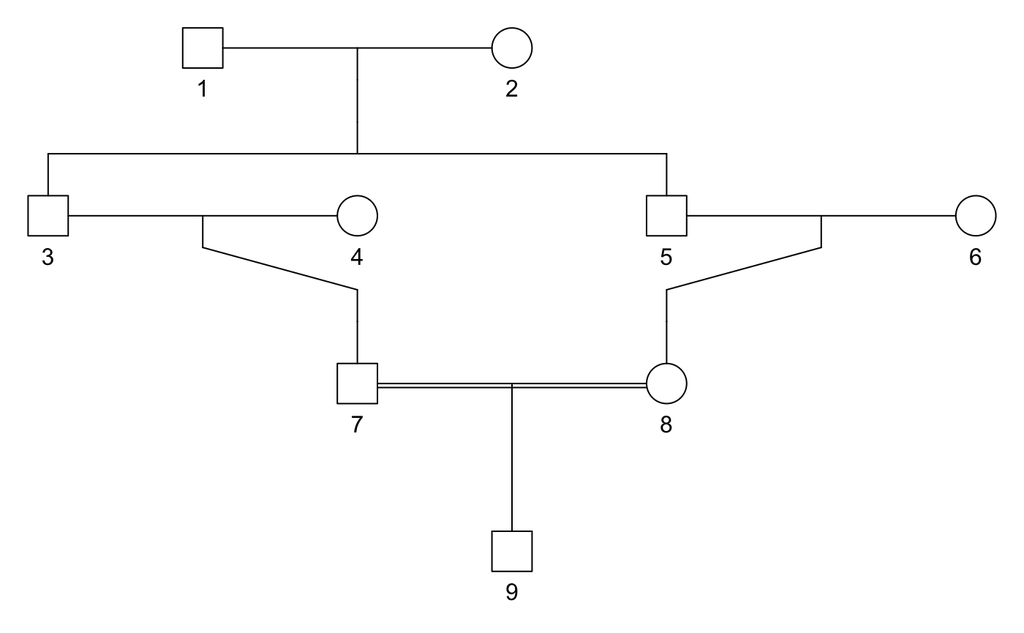

```r
library(pedsuite)
x <- cousinPed(1, child = TRUE)
plot(x)
```

The generated pedigree can be converted to a tibble

```r
library(dplyr)
tbl_cousin <- tibble::as_tibble(x)
(tbl_cousin_with_parents <- tbl_cousin %>%
  filter(fid != 0 & mid != 0) %>%
    select(id, fid, mid))
```

| id | fid | mid |
| --- | --- | --- |
| 3 | 1 | 2 |
| 5 | 1 | 2 |
| 7 | 3 | 4 |
| 8 | 5 | 6 |
| 9 | 7 | 8 |

```r
NA
```

Adding ages of owners to each of the animals

```r
(tbl_cousin_with_parents_with_owner_age <- tbl_cousin_with_parents %>%
  bind_cols(tibble::tibble(AgeOwner = round(rnorm(nrow(tbl_cousin_with_parents), mean = 75, sd = 3), digits = 0))))
```

| id | fid | mid | AgeOwner |
| --- | --- | --- | --- |
| 3 | 1 | 2 | 78 |
| 5 | 1 | 2 | 71 |
| 7 | 3 | 4 | 72 |
| 8 | 5 | 6 | 77 |
| 9 | 7 | 8 | 77 |

Remap the data to IDs which are from different spaces.

```r
vec_ids <- base::union(base::union(tbl_cousin_with_parents$id, tbl_cousin_with_parents$fid), tbl_cousin_with_parents$mid)
tbl_id_map <- tibble::tibble(src_id = vec_ids,
                             trg_id = sapply(runif(length(vec_ids), min = 114000220, max = 114000399), function(x) paste0("CH", floor(x)), USE.NAMES = FALSE))
tbl_id_map
```

| src_id | trg_id |
| --- | --- |
| 3 | CH114000313 |
| 5 | CH114000368 |
| 7 | CH114000285 |
| 8 | CH114000256 |
| 9 | CH114000397 |
| 1 | CH114000329 |
| 2 | CH114000277 |
| 4 | CH114000255 |
| 6 | CH114000248 |

```r
tbl_cousin_with_parents_with_owner_age_remap <- tbl_cousin_with_parents_with_owner_age %>%
  left_join(tbl_id_map, by = c("id" = "src_id")) %>%
  rename(Animal = trg_id)
tbl_cousin_with_parents_with_owner_age_remap <- tbl_cousin_with_parents_with_owner_age_remap %>%
  left_join(tbl_id_map, by = c("fid" = "src_id")) %>%
  rename(Sire = trg_id)
tbl_cousin_with_parents_with_owner_age_remap <- tbl_cousin_with_parents_with_owner_age_remap %>%
  left_join(tbl_id_map, by = c("mid" = "src_id")) %>%
  rename(Dam = trg_id)
(tbl_cousin_with_parents_with_owner_age_remap <- tbl_cousin_with_parents_with_owner_age_remap %>%
  select(Animal, Sire, Dam, AgeOwner))
```

| Animal | Sire | Dam | AgeOwner |
| --- | --- | --- | --- |
| CH114000313 | CH114000329 | CH114000277 | 78 |
| CH114000368 | CH114000329 | CH114000277 | 71 |
| CH114000285 | CH114000313 | CH114000255 | 72 |
| CH114000256 | CH114000368 | CH114000248 | 77 |
| CH114000397 | CH114000285 | CH114000256 | 77 |

```r
NA
```

Writing the pedigree to a file

```r
s_ped1_path <- "lbgfs2022_exam_problem2_pedigree1.csv"
readr::write_delim(tbl_cousin_with_parents_with_owner_age_remap, s_ped1_path, delim = ",")
```

## Half-Sib Pedigree with Inbred Child

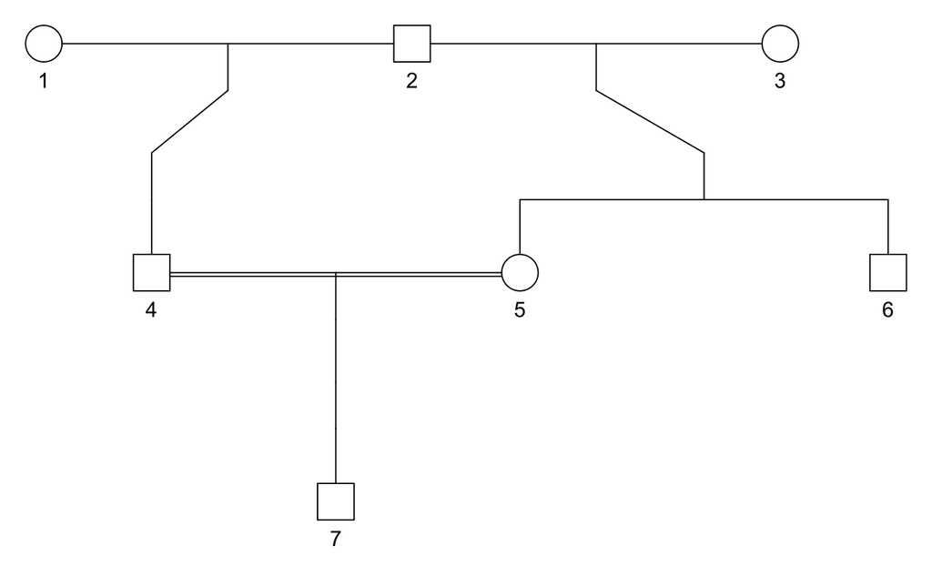

```r
x1 = halfSibPed(nch1 = 1, nch2 = 2, sex1 = 1, sex2 = 2:1) |>
  addSon(parents = 4:5)
plot(x1)
```

Converting it to a tibble

```r
tbl_half_sib <- tibble::as_tibble(x1)
(tbl_half_sib_with_parents <- tbl_half_sib %>%
  filter(fid != 0 & mid != 0) %>%
    select(id, fid, mid))
```

| id | fid | mid |
| --- | --- | --- |
| 4 | 2 | 1 |
| 5 | 2 | 3 |
| 6 | 2 | 3 |
| 7 | 4 | 5 |

Adding ages of owners to each of the animals

```r
(tbl_half_sib_with_parents_with_owner_age <- tbl_half_sib_with_parents %>%
  bind_cols(tibble::tibble(AgeOwner = round(rnorm(nrow(tbl_half_sib_with_parents), mean = 54, sd = 4), digits = 0))))
```

| id | fid | mid | AgeOwner |
| --- | --- | --- | --- |
| 4 | 2 | 1 | 51 |
| 5 | 2 | 3 | 53 |
| 6 | 2 | 3 | 52 |
| 7 | 4 | 5 | 54 |

Remap the data to IDs which are from different spaces.

```r
vec_ids <- base::union(base::union(tbl_half_sib_with_parents$id, tbl_half_sib_with_parents$fid), tbl_half_sib_with_parents$mid)
tbl_id_map <- tibble::tibble(src_id = vec_ids,
                             trg_id = sapply(runif(length(vec_ids), min = 115000220, max = 115000399), function(x) paste0("CH", floor(x)), USE.NAMES = FALSE))
tbl_id_map
```

| src_id | trg_id |
| --- | --- |
| 4 | CH115000392 |
| 5 | CH115000319 |
| 6 | CH115000346 |
| 7 | CH115000347 |
| 2 | CH115000277 |
| 1 | CH115000301 |
| 3 | CH115000256 |

```r
tbl_half_sib_with_parents_with_owner_age_remap <- tbl_half_sib_with_parents_with_owner_age %>%
  left_join(tbl_id_map, by = c("id" = "src_id")) %>%
  rename(Animal = trg_id)
tbl_half_sib_with_parents_with_owner_age_remap <- tbl_half_sib_with_parents_with_owner_age_remap %>%
  left_join(tbl_id_map, by = c("fid" = "src_id")) %>%
  rename(Sire = trg_id)
tbl_half_sib_with_parents_with_owner_age_remap <- tbl_half_sib_with_parents_with_owner_age_remap %>%
  left_join(tbl_id_map, by = c("mid" = "src_id")) %>%
  rename(Dam = trg_id)
(tbl_half_sib_with_parents_with_owner_age_remap <- tbl_half_sib_with_parents_with_owner_age_remap %>%
  select(Animal, Sire, Dam, AgeOwner))
```

| Animal | Sire | Dam | AgeOwner |
| --- | --- | --- | --- |
| CH115000392 | CH115000277 | CH115000301 | 51 |
| CH115000319 | CH115000277 | CH115000256 | 53 |
| CH115000346 | CH115000277 | CH115000256 | 52 |
| CH115000347 | CH115000392 | CH115000319 | 54 |

```r
NA
```

Writing the pedigree to a file

```r
s_ped2_path <- "lbgfs2022_exam_problem2_pedigree2.csv"
readr::write_delim(tbl_half_sib_with_parents_with_owner_age_remap, s_ped2_path, delim = ",")
```

## Data

The data is taken from pedigrees of WAS (`/qualstorzws01/data_projekte/projekte/genmon/pedigrees/PopReport_WAS_mit_20210115.csv_adaptfin5.csv`):

```
1010779957|1004634509|1005998580|2020-10-29|M|3942|0||0
1010779958|1004634509|1005998580|2020-10-29|F|3942|0||0
1005998580|1000171975|1000719353|2016-10-02|F|3942|0||0
1009031358|1004634509|1005998580|2018-09-15|M|3942|0||0
1004634509|999147646|999222110|2015-05-02|M|3984|0||0
```

This data is not needed so far.

## Solution

In subtask a) the numerator relationship matrices must be constructed

### Numerator Relationship Matrix

```r
tbl_ped1 <- readr::read_delim(file = s_ped1_path,
                              delim = ",",
                              col_types = readr::cols(
                                Animal = readr::col_character(),
                                Sire = readr::col_character(),
                                Dam = readr::col_character(),
                                AgeOwner = readr::col_double()
                              ))
tbl_ped1
```

| Animal | Sire | Dam | AgeOwner |
| --- | --- | --- | --- |
| CH114000313 | CH114000329 | CH114000277 | 78 |
| CH114000368 | CH114000329 | CH114000277 | 71 |
| CH114000285 | CH114000313 | CH114000255 | 72 |
| CH114000256 | CH114000368 | CH114000248 | 77 |
| CH114000397 | CH114000285 | CH114000256 | 77 |

Check whether sire and dams are already in pedigree and determine the founder animals to be added to the pedigree

```r
vec_sire_founder <- unique(tbl_ped1$Sire)
vec_sire_founder <- vec_sire_founder[!is.element(vec_sire_founder, tbl_ped1$Animal)]
vec_dam_founder <- unique(tbl_ped1$Dam)
vec_dam_founder <- vec_dam_founder[!is.element(vec_dam_founder, tbl_ped1$Animal)]
vec_founder <- c(vec_sire_founder, vec_dam_founder)
```

Add founders to the pedigree

```r
n_nr_founder <- length(vec_founder)
tbl_ped1_founder <- tibble::tibble(Animal = vec_founder, Sire = rep(NA, n_nr_founder), Dam = rep(NA, n_nr_founder), AgeOwner = rep(NA, n_nr_founder))
tbl_ped1_aug <- dplyr::bind_rows(tbl_ped1_founder, tbl_ped1)
tbl_ped1_aug
```

| Animal | Sire | Dam | AgeOwner |
| --- | --- | --- | --- |
| CH114000329 | NA | NA | NA |
| CH114000277 | NA | NA | NA |
| CH114000255 | NA | NA | NA |
| CH114000248 | NA | NA | NA |
| CH114000313 | CH114000329 | CH114000277 | 78 |
| CH114000368 | CH114000329 | CH114000277 | 71 |
| CH114000285 | CH114000313 | CH114000255 | 72 |
| CH114000256 | CH114000368 | CH114000248 | 77 |
| CH114000397 | CH114000285 | CH114000256 | 77 |

To be able to use `pedigreemm` for computing the numerator relationship matrix, animals must have integer IDs. Hence, we map the character IDs back to integer IDs.

```r
tbl_ped_ID_map <- tibble::tibble(DomainCharId = tbl_ped1_aug$Animal,
                                 ImageIntId = c(1:length(tbl_ped1_aug$Animal)))
tbl_ped_ID_map
```

| DomainCharId | ImageIntId |
| --- | --- |
| CH114000329 | 1 |
| CH114000277 | 2 |
| CH114000255 | 3 |
| CH114000248 | 4 |
| CH114000313 | 5 |
| CH114000368 | 6 |
| CH114000285 | 7 |
| CH114000256 | 8 |
| CH114000397 | 9 |

Do the mapping via joins

```r
library(dplyr)
# Animals
tbl_ped1_int_id <- tbl_ped1_aug %>%
  left_join(tbl_ped_ID_map, by = c("Animal" = "DomainCharId")) %>%
  rename(AnimalIntId = ImageIntId)
# Sire
tbl_ped1_int_id <- tbl_ped1_int_id %>%
  left_join(tbl_ped_ID_map, by = c("Sire" = "DomainCharId")) %>%
  rename(SireIntId = ImageIntId)
# Dam
tbl_ped1_int_id <- tbl_ped1_int_id %>%
  left_join(tbl_ped_ID_map, by = c("Dam" = "DomainCharId")) %>%
  rename(DamIntId = ImageIntId)
tbl_ped1_int_id
```

| Animal | Sire | Dam | AgeOwner | AnimalIntId | SireIntId | DamIntId |
| --- | --- | --- | --- | --- | --- | --- |
| CH114000329 | NA | NA | NA | 1 | NA | NA |
| CH114000277 | NA | NA | NA | 2 | NA | NA |
| CH114000255 | NA | NA | NA | 3 | NA | NA |
| CH114000248 | NA | NA | NA | 4 | NA | NA |
| CH114000313 | CH114000329 | CH114000277 | 78 | 5 | 1 | 2 |
| CH114000368 | CH114000329 | CH114000277 | 71 | 6 | 1 | 2 |
| CH114000285 | CH114000313 | CH114000255 | 72 | 7 | 5 | 3 |
| CH114000256 | CH114000368 | CH114000248 | 77 | 8 | 6 | 4 |
| CH114000397 | CH114000285 | CH114000256 | 77 | 9 | 7 | 8 |

The numerator relationship

```r
ped_ped1 <- pedigreemm::pedigree(sire = tbl_ped1_int_id$SireIntId,
                                 dam =  tbl_ped1_int_id$DamIntId,
                                 label = as.character(tbl_ped1_int_id$AnimalIntId))
pedigreemm::getA(ped = ped_ped1)
```

```
as(<dtTMatrix>, "dtCMatrix") is deprecated since Matrix 1.5-0; do as(., "CsparseMatrix") instead
```

```
9 x 9 sparse Matrix of class "dsCMatrix"
     1    2    3    4     5     6      7      8      9
1 1.00 .    .    .    0.500 0.500 0.2500 0.2500 0.2500
2 .    1.00 .    .    0.500 0.500 0.2500 0.2500 0.2500
3 .    .    1.00 .    .     .     0.5000 .      0.2500
4 .    .    .    1.00 .     .     .      0.5000 0.2500
5 0.50 0.50 .    .    1.000 0.500 0.5000 0.2500 0.3750
6 0.50 0.50 .    .    0.500 1.000 0.2500 0.5000 0.3750
7 0.25 0.25 0.50 .    0.500 0.250 1.0000 0.1250 0.5625
8 0.25 0.25 .    0.50 0.250 0.500 0.1250 1.0000 0.5625
9 0.25 0.25 0.25 0.25 0.375 0.375 0.5625 0.5625 1.0625
```

Same for pedigree 2

```r
# read data
tbl_ped2 <- readr::read_delim(file = s_ped2_path,
                              delim = ",",
                              col_types = readr::cols(
                                Animal = readr::col_character(),
                                Sire = readr::col_character(),
                                Dam = readr::col_character(),
                                AgeOwner = readr::col_double()
                              ))
tbl_ped2
```

| Animal | Sire | Dam | AgeOwner |
| --- | --- | --- | --- |
| CH115000392 | CH115000277 | CH115000301 | 51 |
| CH115000319 | CH115000277 | CH115000256 | 53 |
| CH115000346 | CH115000277 | CH115000256 | 52 |
| CH115000347 | CH115000392 | CH115000319 | 54 |

```r
# add founders
vec_sire_founder <- unique(tbl_ped2$Sire)
vec_sire_founder <- vec_sire_founder[!is.element(vec_sire_founder, tbl_ped2$Animal)]
vec_dam_founder <- unique(tbl_ped2$Dam)
vec_dam_founder <- vec_dam_founder[!is.element(vec_dam_founder, tbl_ped2$Animal)]
vec_founder <- c(vec_sire_founder, vec_dam_founder)
n_nr_founder <- length(vec_founder)
tbl_ped2_founder <- tibble::tibble(Animal = vec_founder, Sire = rep(NA, n_nr_founder), Dam = rep(NA, n_nr_founder), AgeOwner = rep(NA, n_nr_founder))
tbl_ped2_aug <- dplyr::bind_rows(tbl_ped2_founder, tbl_ped2)
tbl_ped2_aug
```

| Animal | Sire | Dam | AgeOwner |
| --- | --- | --- | --- |
| CH115000277 | NA | NA | NA |
| CH115000301 | NA | NA | NA |
| CH115000256 | NA | NA | NA |
| CH115000392 | CH115000277 | CH115000301 | 51 |
| CH115000319 | CH115000277 | CH115000256 | 53 |
| CH115000346 | CH115000277 | CH115000256 | 52 |
| CH115000347 | CH115000392 | CH115000319 | 54 |

```r
# mapping to integer IDs
tbl_ped_ID_map <- tibble::tibble(DomainCharId = tbl_ped2_aug$Animal,
                                 ImageIntId = c(1:length(tbl_ped2_aug$Animal)))
tbl_ped_ID_map
```

| DomainCharId | ImageIntId |
| --- | --- |
| CH115000277 | 1 |
| CH115000301 | 2 |
| CH115000256 | 3 |
| CH115000392 | 4 |
| CH115000319 | 5 |
| CH115000346 | 6 |
| CH115000347 | 7 |

```r
library(dplyr)
# Animals
tbl_ped2_int_id <- tbl_ped2_aug %>%
  left_join(tbl_ped_ID_map, by = c("Animal" = "DomainCharId")) %>%
  rename(AnimalIntId = ImageIntId)
# Sire
tbl_ped2_int_id <- tbl_ped2_int_id %>%
  left_join(tbl_ped_ID_map, by = c("Sire" = "DomainCharId")) %>%
  rename(SireIntId = ImageIntId)
# Dam
tbl_ped2_int_id <- tbl_ped2_int_id %>%
  left_join(tbl_ped_ID_map, by = c("Dam" = "DomainCharId")) %>%
  rename(DamIntId = ImageIntId)
tbl_ped2_int_id
```

| Animal | Sire | Dam | AgeOwner | AnimalIntId | SireIntId | DamIntId |
| --- | --- | --- | --- | --- | --- | --- |
| CH115000277 | NA | NA | NA | 1 | NA | NA |
| CH115000301 | NA | NA | NA | 2 | NA | NA |
| CH115000256 | NA | NA | NA | 3 | NA | NA |
| CH115000392 | CH115000277 | CH115000301 | 51 | 4 | 1 | 2 |
| CH115000319 | CH115000277 | CH115000256 | 53 | 5 | 1 | 3 |
| CH115000346 | CH115000277 | CH115000256 | 52 | 6 | 1 | 3 |
| CH115000347 | CH115000392 | CH115000319 | 54 | 7 | 4 | 5 |

```r
#
ped_ped2 <- pedigreemm::pedigree(sire = tbl_ped2_int_id$SireIntId,
                                 dam =  tbl_ped2_int_id$DamIntId,
                                 label = as.character(tbl_ped2_int_id$AnimalIntId))
pedigreemm::getA(ped = ped_ped2)
```

```
7 x 7 sparse Matrix of class "dsCMatrix"
    1    2    3     4     5     6     7
1 1.0 .    .    0.500 0.500 0.500 0.500
2 .   1.00 .    0.500 .     .     0.250
3 .   .    1.00 .     0.500 0.500 0.250
4 0.5 0.50 .    1.000 0.250 0.250 0.625
5 0.5 .    0.50 0.250 1.000 0.500 0.625
6 0.5 .    0.50 0.250 0.500 1.000 0.375
7 0.5 0.25 0.25 0.625 0.625 0.375 1.125
```